# Project

```python
# Using groupby creating a variable containing bottom 10 Channels having minimum number of videos.
data.groupby('channel_title')['title'].count().to_frame().reset_index().sort_values(by='title',ascending=True).head(10)
```

|  | channel_title | title |
| --- | --- | --- |
| 0 | SilverName | 1 |
| 6089 | Mini Muka | 1 |
| 6088 | Mini Ladd | 1 |
| 6085 | MindYourLogic | 1 |
| 6084 | Mind Body Tonic With Dr Sita | 1 |
| 6082 | Mimi Ar | 1 |
| 6080 | Millyz | 1 |
| 6077 | Milkair | 1 |
| 6076 | Milissa Grande | 1 |
| 6071 | MikuruSong | 1 |

Q11. Find the title of the video which has the maximum number of likes and the title of the video having minimum likes and write your inferences.

```python
data.groupby('title')['likes'].max().to_frame().reset_index().sort_values(by='likes',ascending=False).head(2)
```

|  | title | likes |
| --- | --- | --- |
| 5256 | BTS () 'Dynamite' Official MV | 31837675 |
| 5251 | BTS () 'Butter' Official MV | 20649409 |

```python
data.groupby('title')['likes'].min().to_frame().reset_index().sort_values(by='likes',ascending=True).head(2)
```

|  | title | likes |
| --- | --- | --- |
| 18372 | Kim Kardashian's Must-See Moments on "Saturday... | 0 |
| 19382 | Leading the Charge \| Circle K | 22 |

```python
#The maximum number of likes is BTS () 'Dynamite' Official MV having 31837675
#The minimum number of likes is Kim Kardashian's Must-See Moments on "Saturday Night Live" | E! News having 0
#It is also observed that the videos having higher number of likes are having higher number of views too.
```

Q12. Find the title of the video which has the maximum number of dislikes and the title of the video having minimum dislikes and write your inferences.

```python
data.groupby('title')['dislikes'].max().to_frame().reset_index().sort_values(by='dislikes',ascending=False).head(2)
```

|  | title | dislikes |
| --- | --- | --- |
| 8273 | Cuties \| Official Trailer \| Netflix | 2397733 |
| 5256 | BTS () 'Dynamite' Official MV | 1814333 |

```python
data.groupby('title')['dislikes'].min().to_frame().reset_index().sort_values(by='dislikes',ascending=True).head(2)
```

|  | title | dislikes |
| --- | --- | --- |
| 18372 | Kim Kardashian's Must-See Moments on "Saturday... | 0 |
| 31820 | Tims For Good: A Taste Of The Familiar | 3 |

```python
'''The maximum number of dislikes is Cuties | Official Trailer | Netflix having 2397733
The minimum number of dislikes is Kim Kardashian's Must-See Moments on "Saturday Night Live" | E! News having 0
It is also observed that the videos having least number of dislikes and likes is Kim Kardashian's Must-See Moments on "Saturday Night Live" | E! News'''
```

```
'The maximum number of dislikes is Cuties | Official Trailer | Netflix having 2397733\nThe minimum number of dislikes is Kim Kardashian\'s Must-See Moments on "Saturday Night Live" | E! News having 0\nIt is also observed that the videos having least number of dislikes and likes is Kim Kardashian\'s …
```

Q13. Does the number of views have any effect on how many people disliked the video? Support your answer with a metric and a plot.

```python
data['view_count'].corr(data['dislikes'])
```

```
0.6844687753905542
```

```python
import matplotlib.pyplot as plt
```

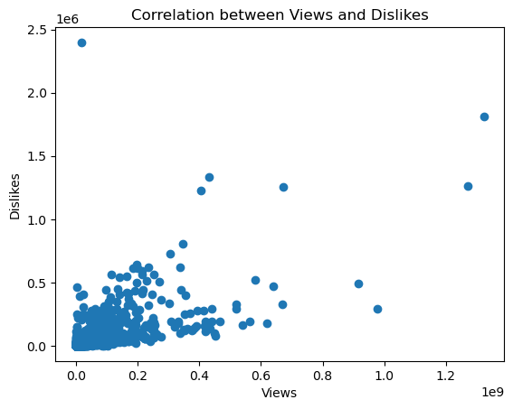

```python
plt.scatter(data["view_count"], data["dislikes"])
plt.xlabel("Views")
plt.ylabel("Dislikes")
plt.title("Correlation between Views and Dislikes")
plt.show()
```

```python
#The correlation between views and dislikes is 0.684.
#It means it's having a direct relation and increase in one leads to increase in another and vice-versa.
```

Q14. Display all the information about the videos that were published in January, and mention the count of videos that were published in January.

```python
jan_videos = data[data['published_month'] == 'Jan']
jan_videos
```

|  | video_id | title | channel_id | channel_title | published_at | view_count | likes | dislikes | comment_count | tags | description | published_month |
| --- | --- | --- | --- | --- | --- | --- | --- | --- | --- | --- | --- | --- |
| 27 | -2Gwm7QfBnE | Q&A With Naisha | UCYwNMbogQFzMccPSuy-pPWg | MianTwins | 2021-01-21 00:05:47 | 872372 | 38626 | 239 | 621 |  | Hey Guys!!! this has been the most requested v... | Jan |
| 48 | -4sfXSHSxzA | SURPRISING BRENT WITH HIS TIKTOK CRUSH!! | UCPpATKqmMV-CNRNWYaDUwiA | Alexa Rivera | 2021-01-16 21:40:04 | 6504784 | 262477 | 5779 | 7907 |  | He had no idea! Thank you guys so much for wat... | Jan |
| 95 | -AJD1Fc5rpQ | WE ARE HAVING A BABY! \| finding out i'm pregna... | UCVsTboAhpnuL6j-tDePvNwQ | Tess Christine | 2021-01-03 21:53:48 | 533084 | 38965 | 119 | 1650 |  | I am so happy to tell you that I am pregnant!!... | Jan |
| 103 | -AuJiwjsmWk | Do Ugly Foods Taste Worse? Taste Test | UCzpCc5n9hqiVC7HhPwcIKEg | Good Mythical MORE | 2021-01-19 11:00:01 | 1057077 | 22526 | 531 | 773 | gmm good mythical morning rhettandlink rhett a... | Today, we're doing a blind taste test to deter... | Jan |
| 182 | -JhqO2KWr5U | Schlatt gets fit | UCWZp4y1jqBuvLtiyxSs_ZBw | Big guy | 2021-01-24 22:50:57 | 1724965 | 119431 | 325 | 1578 | jschlatt big guy jschlatt highlights schlatt j... | #jschlatt #schlatt #bigguy #short | Jan |
| ... | ... | ... | ... | ... | ... | ... | ... | ... | ... | ... | ... | ... |
| 37300 | zmzFL5bG-jc | DEVINE MON PERSONNAGE AVANT AKINATOR ! (c'est ... | UCIlr3byh6wmXgcPx_Tm9Ocw | Piwerre | 2021-01-16 16:12:19 | 670357 | 54462 | 832 | 1249 | Piwerre frere de michou crouton among us devin... | Discord Piwerre : https://discord.gg/QBduPgAA... | Jan |
| 37329 | zpzjex7qwrA | Lampard Sacked Within Days Rorys Misery \| Chel... | UCkD-ZOixI0a9FjIExDsHsbg | The Kick Off | 2021-01-03 20:13:49 | 428646 | 12060 | 296 | 1505 | Premier league Chelsea chelsea 1-3 Man City Ch... | The Kick Off watched Manchester City destroy C... | Jan |
| 37345 | zqyv-B6mnBM | Lil Wayne - Ain't Got Time (Audio) | UCO9zJy7HWrIS3ojB4Lr7Yqw | Lil Wayne | 2021-01-21 05:00:10 | 2238244 | 58925 | 2365 | 5539 | lil wayne weezy weezy wednesday wayne carter y... | Official audio for Lil Wayne "Ain't Got Time",... | Jan |
| 37383 | zwfu1-24T7Q | PRADA Cup Day 1 \| Full Race Replay \| PRADA Cup... | UCo15ZYO_XDRU9LI30OPtxAg | America's Cup | 2021-01-15 04:07:55 | 317382 | 2008 | 83 | 192 | America's Cup Americas Cup AC36 AC75 Presented... | The opening day of the PRADA Cup in Auckland, ... | Jan |
| 37418 | zziBybeSAtw | PELICANS at LAKERS \| FULL GAME HIGHLIGHTS \| Ja... | UCWJ2lWNubArHWmf3FIHbfcQ | NBA | 2021-01-16 05:39:05 | 2841917 | 20759 | 1049 | 2624 | NBA G League Basketball game-0022000187 Lakers... | PELICANS at LAKERS \| FULL GAME HIGHLIGHTS \| Ja... | Jan |

2108 rows × 12 columns

```python
jan_videos.count()
```

```
video_id           2108
title              2108
channel_id         2108
channel_title      2108
published_at       2108
view_count         2108
likes              2108
dislikes           2108
comment_count      2108
tags               2108
description        2108
published_month    2108
dtype: int64
```